# Muestreo de poblaciones y estimación

AFDMD-111 Estadística

# Introducción

En estadística, los conceptos de población y muestra son sumamente importantes. Población se refiere al conjunto de todos los sujetos de interés, por ejemplo, al estudiar la edad de los estudiantes de la UQRoo Cancún, la población son todos los estudiantes del campus. Muestra, por otro lado, se refiere a un subconjunto de la población. Por ejemplo, los estudiantes que se encuentran en horario de 07:00-09:00 am, los estudiantes que se encuentran en la biblioteca, etc. Usualmente es muy común estudiar a las muestras y entonces para tomar muestras se consideran dos tipos de muestreo.

- Muestreo aleatorio.
- Muestreo no aleatorio.

# Muestreo aleatorio

Existen varios tipos de muestreo aleatorio, entre los cuales encontramos:

- Muestreo aleatorio simple.
- Muestreo sistemático.
- Muestreo estratificado.
- Muestreo de Poisson.

## Muestreo aleatorio simple.

El muestreo se puede realizar mediante el comando `sample`. Por ejemplo una muestra de tamaño $50$ de las primeras $15$ letras minúsculas del abecedario se realiza y grafica como:

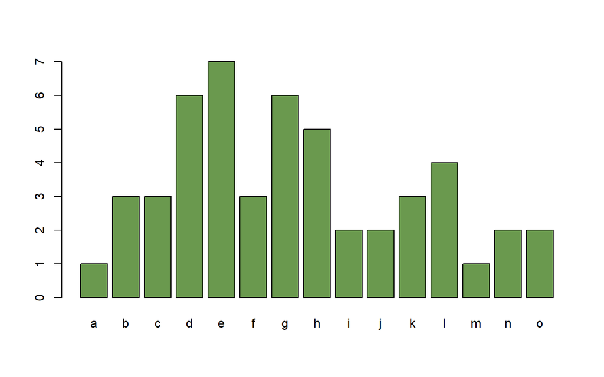

```r
m <- as.factor(sample(letters[1:15], 50, replace=T))
plot(m, col = "#6a994e")
```

Nótese que el comando `sample` tiene como parámetros `replace` y `prob`.

1. ¿Qué sucede si `replace=FALSE` en código anterior?.

R = Si replace se establece en FALSE en el código anterior, significa que no se permitirá el reemplazo de elementos en la muestra. En este caso, cada letra del conjunto letters[1:15] se seleccionará exactamente una vez en la muestra de tamaño 50, y no se permitirá seleccionar la misma letra más de una vez. Esto garantiza que todas las letras en la muestra sean únicas.

Por lo que hubo que cambiar el tamaño de la muestra al salir un error.

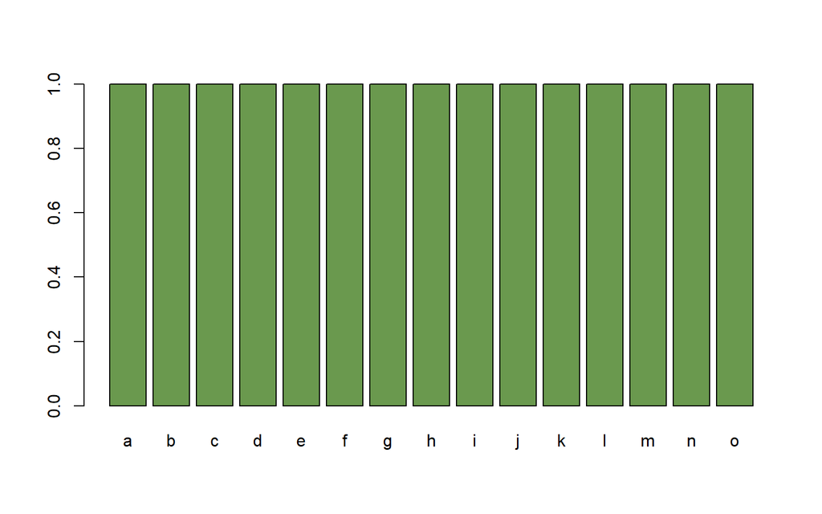

```r
m <- as.factor(sample(letters[1:15], 15, replace=F))
plot(m, col = "#6a994e")
```

2. ¿Cuál es la diferencia entre `sample(letters[1:10],10, replace=T)` y `sample(letters[1:10],10)`?

En el primer caso (sample(letters[1:10], 10, replace = T)), se permite el reemplazo en la selección de elementos, lo que significa que un mismo elemento puede ser seleccionado más de una vez en la muestra. En cambio, en el segundo caso (sample(letters[1:10], 10)), no se permite el reemplazo, lo que implica que cada elemento se selecciona solo una vez en la muestra.

Primer caso:

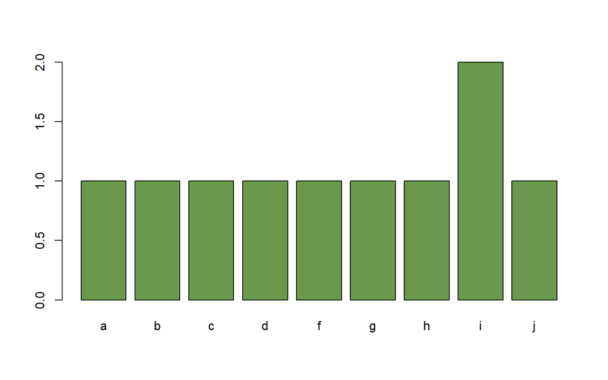

```r
m <- as.factor(sample(letters[1:10],10, replace=T))
plot(m, col = "#6a994e")
```

Segundo Caso:

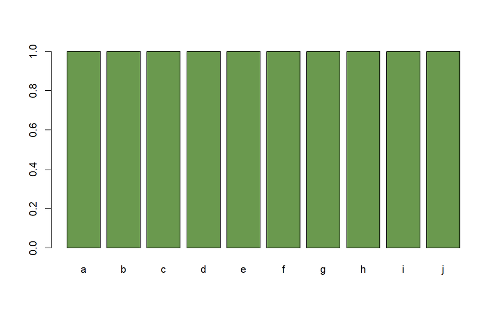

```r
m <- as.factor(sample(letters[1:10],10))
plot(m, col = "#6a994e")
```

3. ¿Y entre `sample(letters[1:6], 10, prob=c(0.5,0.1,0.1,0.1,0.1,0.1), replace = T)` y `sample(letters[1:6], 10, replace=T)`?

En el primer caso `(sample(letters[1:6], 10,prob=c(0.5,0.1,0.1,0.1,0.1,0.1), replace = T))`, se especifican probabilidades de selección para cada elemento del vector. En este ejemplo, la probabilidad de seleccionar el primer elemento es 0.5, mientras que para los elementos restantes es 0.1 cada uno. En el segundo caso `(sample(letters[1:6], 10, replace = T))`, se realiza un muestreo con reemplazo, pero sin especificar probabilidades. En este caso, cada elemento tiene la misma probabilidad de ser seleccionado.

Se muestra a continuación

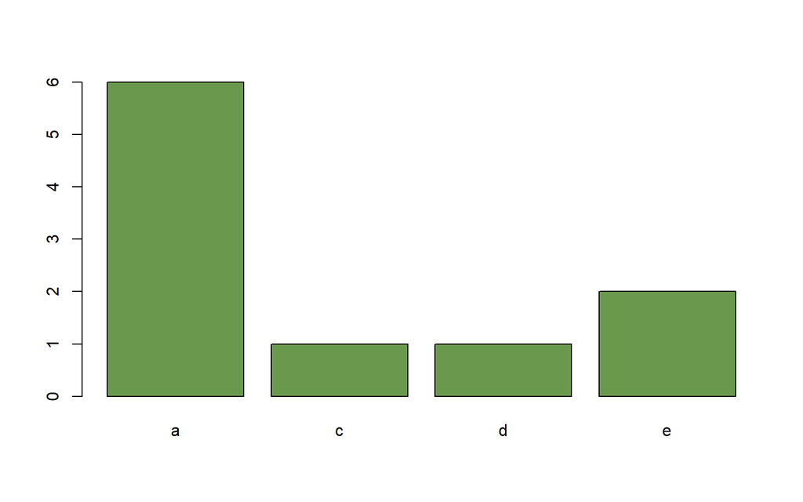

```r
m <- as.factor(sample(letters[1:6], 10, prob=c(0.5,0.1,0.1,0.1,0.1,0.1), replace = T))
plot(m, col = "#6a994e")
```

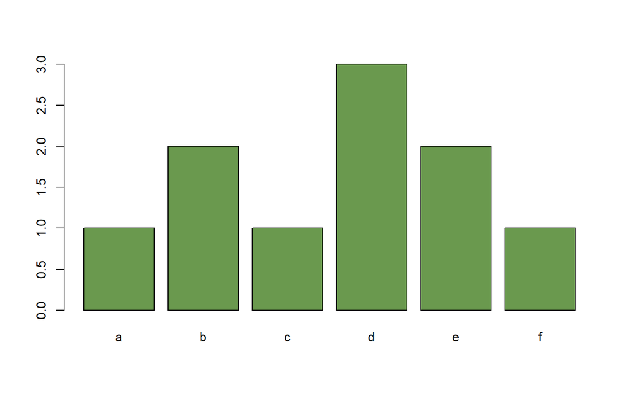

```r
m <- as.factor(sample(letters[1:6], 10, replace=T))
plot(m, col = "#6a994e")
```